# Project_VisitWithUs_Tourism

## Context

You are a Data Scientist for a tourism company named "Visit with us". The Policy Maker of the company wants to enable and establish a viable business model to expand the customer base. A viable business model is a central concept that helps you to understand the existing ways of doing the business and how to change the ways for the benefit of the tourism sector. One of the ways to expand the customer base is to introduce a new offering of packages. Currently, there are 5 types of packages the company is offering - Basic, Standard, Deluxe, Super Deluxe, King. Looking at the data of the last year, we observed that 18% of the customers purchased the packages. However, the marketing cost was quite high because customers were contacted at random without looking at the available information. The company is now planning to launch a new product i.e. Wellness Tourism Package. Wellness Tourism is defined as Travel that allows the traveler to maintain, enhance or kick-start a healthy lifestyle, and support or increase one's sense of well being. However, this time company wants to harness the available data of existing and potential customers to make the marketing expenditure more efficient. You as a Data Scientist at "Visit with us" travel company has to analyze the customers' data and information to provide recommendations to the Policy Maker and Marketing Team and also build a model to predict the potential customer who is going to purchase the newly introduced package.

## Objective

To predict which customer is more likely to purchase the long term travel package.

## Attribute Information:

### Customer Details

1. CustomerID: Unique customer ID
2. ProdTaken: Product taken flag
3. Age: Age of customer
4. PreferredLoginDevice: Preferred login device of the customer in last month
5. CityTier: City tier
6. Occupation: Occupation of customer
7. Gender: Gender of customer
8. NumberOfPersonVisited: Total number of person came with customer
9. PreferredPropertyStar: Preferred hotel property rating by customer
10. MaritalStatus: Marital status of customer
11. NumberOfTrips: Average number of the trip in a year by customer
12. Passport: Customer passport flag
13. OwnCar: Customers owns a car flag
14. NumberOfChildrenVisited: Total number of children visit with customer
15. Designation: Designation of the customer in the current organization
16. MonthlyIncome: Gross monthly income of the customer

### Customer interaction data:

1. PitchSatisfactionScore: Sales pitch satisfactory score
2. ProductPitched: Product pitched by a salesperson
3. NumberOfFollowups: Total number of follow up has been done by sales person after sales pitch
4. DurationOfPitch: Duration of the pitch by a salesman to customer

```python
### Import libraries

import numpy as np
import pandas as pd
import seaborn as sns
sns.set(color_codes=True)
import matplotlib.pyplot as plt
%matplotlib inline

import numpy as np
from scipy import stats

# calculate accuracy measures and confusion matrix
from sklearn import metrics
# import logistic Regression Model
from sklearn.linear_model import LogisticRegression

from sklearn.tree import DecisionTreeClassifier
from sklearn import tree

from sklearn.ensemble import StackingClassifier, AdaBoostClassifier, GradientBoostingClassifier, BaggingClassifier, RandomForestClassifier
from sklearn import metrics
from sklearn.model_selection import GridSearchCV, train_test_split
from xgboost import XGBClassifier

from datetime import datetime
```

```python
Tourism_df = pd.read_excel('Tourism.xlsx', sheet_name="Tourism") #Read in Tourism data
```

**Review Sample of data**

```python
Tourism_df.head(5)
```

|  | CustomerID | ProdTaken | Age | TypeofContact | CityTier | DurationOfPitch | Occupation | Gender | NumberOfPersonVisited | NumberOfFollowups | ProductPitched | PreferredPropertyStar | MaritalStatus | NumberOfTrips | Passport | PitchSatisfactionScore | OwnCar | NumberOfChildrenVisited | Designation | MonthlyIncome |
| --- | --- | --- | --- | --- | --- | --- | --- | --- | --- | --- | --- | --- | --- | --- | --- | --- | --- | --- | --- | --- |
| 0 | 200000 | 1 | 41.0 | Self Enquiry | 3 | 6.0 | Salaried | Female | 3 | 3.0 | Deluxe | 3.0 | Single | 1.0 | 1 | 2 | 1 | 0.0 | Manager | 20993.0 |
| 1 | 200001 | 0 | 49.0 | Company Invited | 1 | 14.0 | Salaried | Male | 3 | 4.0 | Deluxe | 4.0 | Divorced | 2.0 | 0 | 3 | 1 | 2.0 | Manager | 20130.0 |
| 2 | 200002 | 1 | 37.0 | Self Enquiry | 1 | 8.0 | Free Lancer | Male | 3 | 4.0 | Basic | 3.0 | Single | 7.0 | 1 | 3 | 0 | 0.0 | Executive | 17090.0 |
| 3 | 200003 | 0 | 33.0 | Company Invited | 1 | 9.0 | Salaried | Female | 2 | 3.0 | Basic | 3.0 | Divorced | 2.0 | 1 | 5 | 1 | 1.0 | Executive | 17909.0 |
| 4 | 200004 | 0 | NaN | Self Enquiry | 1 | 8.0 | Small Business | Male | 2 | 3.0 | Basic | 4.0 | Divorced | 1.0 | 0 | 5 | 1 | 0.0 | Executive | 18468.0 |

```python
Tourism_df.tail(5)
```

|  | CustomerID | ProdTaken | Age | TypeofContact | CityTier | DurationOfPitch | Occupation | Gender | NumberOfPersonVisited | NumberOfFollowups | ProductPitched | PreferredPropertyStar | MaritalStatus | NumberOfTrips | Passport | PitchSatisfactionScore | OwnCar | NumberOfChildrenVisited | Designation | MonthlyIncome |
| --- | --- | --- | --- | --- | --- | --- | --- | --- | --- | --- | --- | --- | --- | --- | --- | --- | --- | --- | --- | --- |
| 4883 | 204883 | 1 | 49.0 | Self Enquiry | 3 | 9.0 | Small Business | Male | 3 | 5.0 | Deluxe | 4.0 | Unmarried | 2.0 | 1 | 1 | 1 | 1.0 | Manager | 26576.0 |
| 4884 | 204884 | 1 | 28.0 | Company Invited | 1 | 31.0 | Salaried | Male | 4 | 5.0 | Basic | 3.0 | Single | 3.0 | 1 | 3 | 1 | 2.0 | Executive | 21212.0 |
| 4885 | 204885 | 1 | 52.0 | Self Enquiry | 3 | 17.0 | Salaried | Female | 4 | 4.0 | Standard | 4.0 | Married | 7.0 | 0 | 1 | 1 | 3.0 | Senior Manager | 31820.0 |
| 4886 | 204886 | 1 | 19.0 | Self Enquiry | 3 | 16.0 | Small Business | Male | 3 | 4.0 | Basic | 3.0 | Single | 3.0 | 0 | 5 | 0 | 2.0 | Executive | 20289.0 |
| 4887 | 204887 | 1 | 36.0 | Self Enquiry | 1 | 14.0 | Salaried | Male | 4 | 4.0 | Basic | 4.0 | Unmarried | 3.0 | 1 | 3 | 1 | 2.0 | Executive | 24041.0 |

**Check Shape of Data, Check data types and number of non-null values for each column.**

```python
Tourism_df.shape
```

```
(4888, 20)
```

```python
Tourism_df.info()
```

```
<class 'pandas.core.frame.DataFrame'>
RangeIndex: 4888 entries, 0 to 4887
Data columns (total 20 columns):
 #   Column                   Non-Null Count  Dtype
---  ------                   --------------  -----
 0   CustomerID               4888 non-null   int64
 1   ProdTaken                4888 non-null   int64
 2   Age                      4662 non-null   float64
 3   TypeofContact            4863 non-null   object
 4   CityTier                 4888 non-null   int64
 5   DurationOfPitch          4637 non-null   float64
 6   Occupation               4888 non-null   object
 7   Gender                   4888 non-null   object
 8   NumberOfPersonVisited    4888 non-null   int64
 9   NumberOfFollowups        4843 non-null   float64
 10  ProductPitched           4888 non-null   object
 11  PreferredPropertyStar    4862 non-null   float64
 12  MaritalStatus            4888 non-null   object
 13  NumberOfTrips            4748 non-null   float64
 14  Passport                 4888 non-null   int64
 15  PitchSatisfactionScore   4888 non-null   int64
 16  OwnCar                   4888 non-null   int64
 17  NumberOfChildrenVisited  4822 non-null   float64
 18  Designation              4888 non-null   object
 19  MonthlyIncome            4655 non-null   float64
dtypes: float64(7), int64(7), object(6)
memory usage: 763.9+ KB
```

**Insights**

- There are a total of 4,888 observation with 20 Columns
- There are a mix of float64, int64 and object data types
- There are missing values in Age, TypeofContact, DurationOfPitch, NumberOfFollowups, PreferredPropertyStar, NumberOfTrips, NumberOfChildrenVisited, and MonthlyIncome
- There are several object variables. Will need to change those to categorical variables

```python
Tourism_df.isna().sum()
```

```
CustomerID                   0
ProdTaken                    0
Age                        226
TypeofContact               25
CityTier                     0
DurationOfPitch            251
Occupation                   0
Gender                       0
NumberOfPersonVisited        0
NumberOfFollowups           45
ProductPitched               0
PreferredPropertyStar       26
MaritalStatus                0
NumberOfTrips              140
Passport                     0
PitchSatisfactionScore       0
OwnCar                       0
NumberOfChildrenVisited     66
Designation                  0
MonthlyIncome              233
dtype: int64
```

**Insights**

- Confirmed several columns missing values

Lets convert object variables to categorical variables

```python
for feature in Tourism_df.columns: # Loop through all columns in the dataframe
    if Tourism_df[feature].dtype == 'object': # Only apply for columns with categorical strings
        Tourism_df[feature] = pd.Categorical(Tourism_df[feature])# Change to categorical varible
Tourism_df.info()
```

```
<class 'pandas.core.frame.DataFrame'>
RangeIndex: 4888 entries, 0 to 4887
Data columns (total 20 columns):
 #   Column                   Non-Null Count  Dtype
---  ------                   --------------  -----
 0   CustomerID               4888 non-null   int64
 1   ProdTaken                4888 non-null   int64
 2   Age                      4662 non-null   float64
 3   TypeofContact            4863 non-null   category
 4   CityTier                 4888 non-null   int64
 5   DurationOfPitch          4637 non-null   float64
 6   Occupation               4888 non-null   category
 7   Gender                   4888 non-null   category
 8   NumberOfPersonVisited    4888 non-null   int64
 9   NumberOfFollowups        4843 non-null   float64
 10  ProductPitched           4888 non-null   category
 11  PreferredPropertyStar    4862 non-null   float64
 12  MaritalStatus            4888 non-null   category
 13  NumberOfTrips            4748 non-null   float64
 14  Passport                 4888 non-null   int64
 15  PitchSatisfactionScore   4888 non-null   int64
 16  OwnCar                   4888 non-null   int64
 17  NumberOfChildrenVisited  4822 non-null   float64
 18  Designation              4888 non-null   category
 19  MonthlyIncome            4655 non-null   float64
dtypes: category(6), float64(7), int64(7)
memory usage: 564.4 KB
```

**Summary of Data**

```python
Tourism_df.describe().T
```

|  | count | mean | std | min | 25% | 50% | 75% | max |
| --- | --- | --- | --- | --- | --- | --- | --- | --- |
| ProdTaken | 4888.0 | 0.188216 | 0.390925 | 0.0 | 0.0 | 0.0 | 0.0 | 1.0 |
| Age | 4662.0 | 37.622265 | 9.316387 | 18.0 | 31.0 | 36.0 | 44.0 | 61.0 |
| CityTier | 4888.0 | 1.654255 | 0.916583 | 1.0 | 1.0 | 1.0 | 3.0 | 3.0 |
| DurationOfPitch | 4637.0 | 15.490835 | 8.519643 | 5.0 | 9.0 | 13.0 | 20.0 | 127.0 |
| NumberOfPersonVisited | 4888.0 | 2.905074 | 0.724891 | 1.0 | 2.0 | 3.0 | 3.0 | 5.0 |
| NumberOfFollowups | 4843.0 | 3.708445 | 1.002509 | 1.0 | 3.0 | 4.0 | 4.0 | 6.0 |
| PreferredPropertyStar | 4862.0 | 3.581037 | 0.798009 | 3.0 | 3.0 | 3.0 | 4.0 | 5.0 |
| NumberOfTrips | 4748.0 | 3.236521 | 1.849019 | 1.0 | 2.0 | 3.0 | 4.0 | 22.0 |
| Passport | 4888.0 | 0.290917 | 0.454232 | 0.0 | 0.0 | 0.0 | 1.0 | 1.0 |
| PitchSatisfactionScore | 4888.0 | 3.078151 | 1.365792 | 1.0 | 2.0 | 3.0 | 4.0 | 5.0 |
| OwnCar | 4888.0 | 0.620295 | 0.485363 | 0.0 | 0.0 | 1.0 | 1.0 | 1.0 |
| NumberOfChildrenVisited | 4822.0 | 1.187267 | 0.857861 | 0.0 | 1.0 | 1.0 | 2.0 | 3.0 |
| MonthlyIncome | 4655.0 | 23619.853491 | 5380.698361 | 1000.0 | 20346.0 | 22347.0 | 25571.0 | 98678.0 |

**Insights**

- Age, DurationOfPitch, NumberOfTrips and MonthlyIncome are right skewed

```python
Tourism_df.nunique()
```

```
CustomerID                 4888
ProdTaken                     2
Age                          44
TypeofContact                 2
CityTier                      3
DurationOfPitch              34
Occupation                    4
Gender                        3
NumberOfPersonVisited         5
NumberOfFollowups             6
ProductPitched                5
PreferredPropertyStar         3
MaritalStatus                 4
NumberOfTrips                12
Passport                      2
PitchSatisfactionScore        5
OwnCar                        2
NumberOfChildrenVisited       4
Designation                   5
MonthlyIncome              2475
dtype: int64
```

**Insight**

- CustomerID is an Identifier. It is different for each row. Therefore, it can be dropped
- Age, DurationOfPitch,NumberOfTrips, and MonthlyIncome have a decently variety of values
- The rest of the variables can be treated as categorical variables

```python
# Drop CustomerID
Tourism_df.drop(columns=['CustomerID'], inplace=True)
```

```python
cat_cols=['ProdTaken','TypeofContact','CityTier','Occupation','Gender','ProductPitched','PreferredPropertyStar','MaritalStatus','Passport','PitchSatisfactionScore','OwnCar','Designation']

for column in cat_cols:
    print(Tourism_df[column].value_counts())
    print('-'*30)
```

```
0    3968
1     920
Name: ProdTaken, dtype: int64
------------------------------
Self Enquiry       3444
Company Invited    1419
Name: TypeofContact, dtype: int64
------------------------------
1    3190
3    1500
2     198
Name: CityTier, dtype: int64
------------------------------
Salaried          2368
Small Business    2084
Large Business     434
Free Lancer          2
Name: Occupation, dtype: int64
------------------------------
Male       2916
Female     1817
Fe Male     155
Name: Gender, dtype: int64
------------------------------
Basic           1842
Deluxe          1732
Standard         742
Super Deluxe     342
King             230
Name: ProductPitched, dtype: int64
------------------------------
3.0    2993
5.0     956
4.0     913
Name: PreferredPropertyStar, dtype: int64
------------------------------
Married      2340
Divorced      950
Single        916
Unmarried     682
```

[output cut: 9 more lines]

```
4     912
2     586
Name: PitchSatisfactionScore, dtype: int64
------------------------------
1    3032
0    1856
Name: OwnCar, dtype: int64
------------------------------
Executive         1842
Manager           1732
Senior Manager     742
AVP                342
VP                 230
Name: Designation, dtype: int64
------------------------------
```

**Insights**

- Gender has three categories. Wil want to map Fe Male to Female

## Perform an Exploratory Data Analysis on the data

### Univariate analysis

```python
#Function to create Histogram and Boxplot
def histogram_boxplot(feature, figsize=(15,10), bins = None):
    """ Boxplot and histogram combined
    feature: 1-d feature array
    figsize: size of fig (default (9,8))
    bins: number of bins (default None / auto)
    """
    f2, (ax_box2, ax_hist2) = plt.subplots(nrows = 2,
                                           sharex = True,
                                           gridspec_kw = {"height_ratios": (.25, .75)},
                                           figsize = figsize
                                           )
    sns.boxplot(feature, ax=ax_box2, showmeans=True, color='violet')
    sns.distplot(feature, kde=F, ax=ax_hist2, bins=bins,palette="winter") if bins else sns.distplot(feature, kde=False, ax=ax_hist2)
    ax_hist2.axvline(np.mean(feature), color='green', linestyle='--')
    ax_hist2.axvline(np.median(feature), color='black', linestyle='-')
```

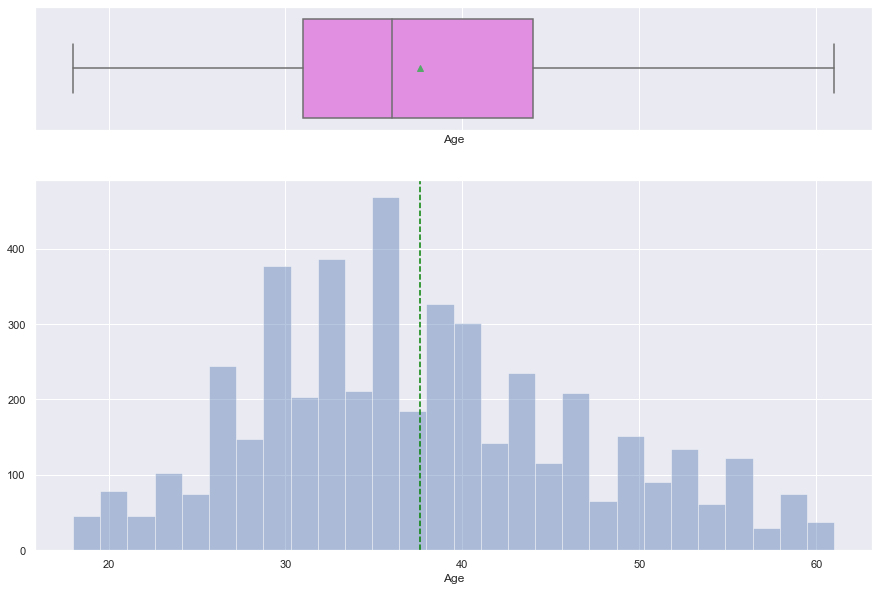

```python
histogram_boxplot(Tourism_df['Age'])
```

**Insight**

- Age is slightly right skewed

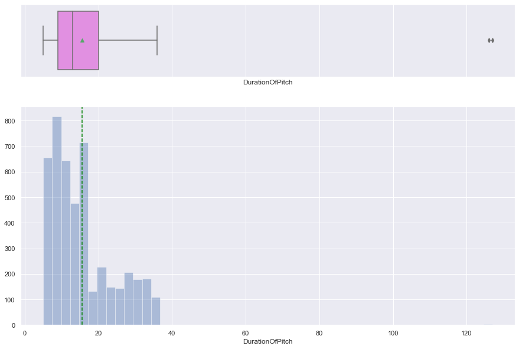

```python
histogram_boxplot(Tourism_df['DurationOfPitch'])
```

```python
#Top 5 highest values
Tourism_df['DurationOfPitch'].nlargest()
```

```
3878    127.0
1434    126.0
2505     36.0
2585     36.0
2643     36.0
Name: DurationOfPitch, dtype: float64
```

**Insight**

- DurationOfPitch has 2 extreme outliers of 126 and 127. These will need to be reviewed as it might be data entry error.

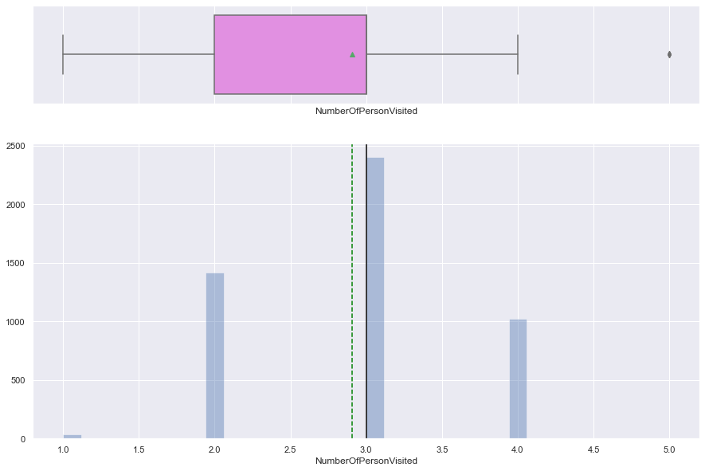

```python
histogram_boxplot(Tourism_df['NumberOfPersonVisited'])
```

**Insight**

- 3 is overwhelming Number of persons that visited. There is not much variety in NumberOfPersonsVisited

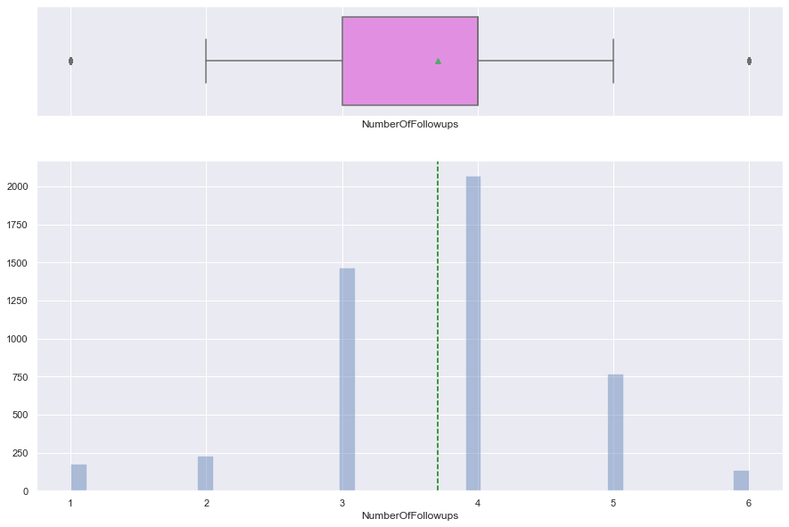

```python
histogram_boxplot(Tourism_df['NumberOfFollowups'])
```

**Insight**

- 4 followups is the most common followup number.

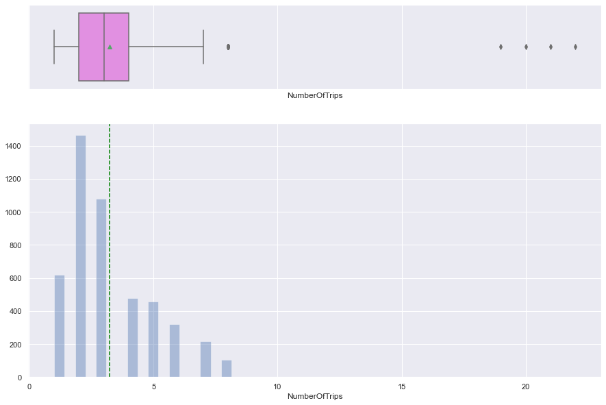

```python
histogram_boxplot(Tourism_df['NumberOfTrips'])
```

**Insights**

- Right skewed with a couple of large outliers

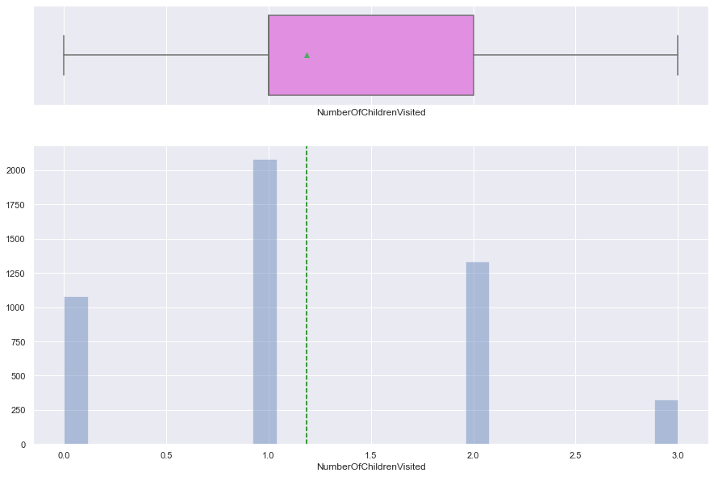

```python
histogram_boxplot(Tourism_df['NumberOfChildrenVisited'])
```

**Insight** One is the most common amount of children that visit.

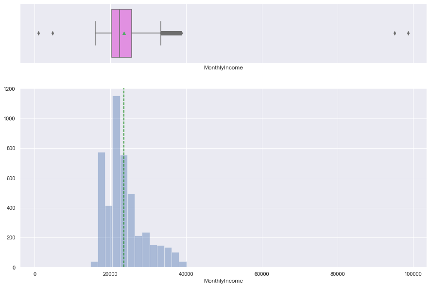

```python
histogram_boxplot(Tourism_df['MonthlyIncome'])
```

```python
#Top 5 highest values
Tourism_df['MonthlyIncome'].nlargest()
```

```
2482    98678.0
38      95000.0
2634    38677.0
4104    38677.0
3190    38651.0
Name: MonthlyIncome, dtype: float64
```

**Insight**

- MonthlyIncome is right skewed. With two large outliers of 98k and 95k

## Review Categorical Variables

**Function to create Bar Charts of percentages**

```python
def perc_on_bar(feature):

    sns.set(rc={'figure.figsize':(5,3)})
    ax=sns.countplot(x=feature, data=Tourism_df)

    total = len(feature)
    for p in ax.patches:
        percentage = '{:.1f}%'.format(100 * p.get_height()/total)
        x = p.get_x() + p.get_width() / 2 - 0.25
        y = p.get_y() + p.get_height()
        ax.annotate(percentage, (x, y), size = 10)

    plt.show()
```

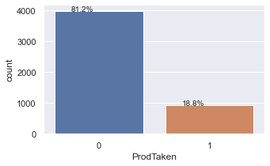

```python
perc_on_bar(Tourism_df['ProdTaken'])
```

**Insights**

- 18.8% of customers take product
- Also, ProdTaken is our target variable
- It is weighted heavily to zero, but at least great than 10% of the data contains 1

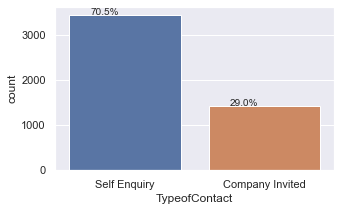

```python
perc_on_bar(Tourism_df['TypeofContact'])
```

**Insights**

- Most of the contact type is a self Enquiry
- This might mean that here is potential for more targeted Company Invite

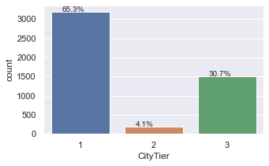

```python
perc_on_bar(Tourism_df['CityTier'])
```

**Insights**

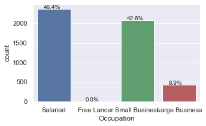

```python
perc_on_bar(Tourism_df['Occupation'])
```

**Insights**

- Free Lancer and Larget Business are small part of the occupation category

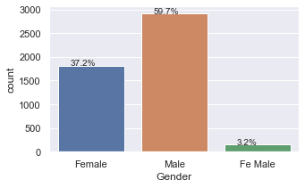

```python
perc_on_bar(Tourism_df['Gender'])
```

**Insights**

- There is a data error with mispelled Fe Male Category. This will need corrected
- Majority of the customers are Male

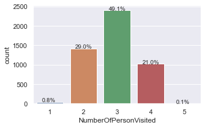

```python
perc_on_bar(Tourism_df['NumberOfPersonVisited'])
```

**Insights**

- Three is the most common number of people that visit. With Categories 1 and 5, being less than 1% of total

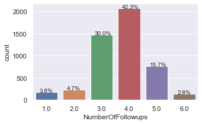

```python
perc_on_bar(Tourism_df['NumberOfFollowups'])
```

**Insights**

- 70% of the follow ups fall in categories 3 and 4

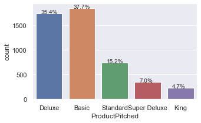

```python
perc_on_bar(Tourism_df['ProductPitched'])
```

**Insights**

- Deluxe and Basic products are the most common and with both around 35% of the total

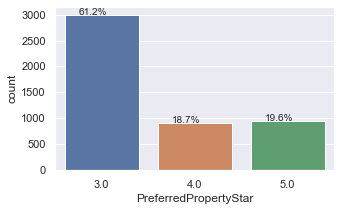

```python
perc_on_bar(Tourism_df['PreferredPropertyStar'])
```

**Insights**

- There are none preferred property stars below 3
- 3 starred prorperty is the most common preference

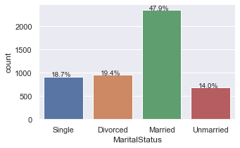

```python
perc_on_bar(Tourism_df['MaritalStatus'])
```

**Insights**

- Almost half of the customers are Married.
- The other 3 categories are similar in percentage

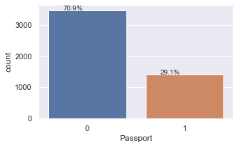

```python
perc_on_bar(Tourism_df['Passport'])
```

**Insights**

- 71% of the customers do not have a passport

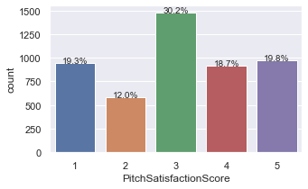

```python
perc_on_bar(Tourism_df['PitchSatisfactionScore'])
```

**Insights**

- The Pitch Satisfaction score is symmetrically distributed around 3

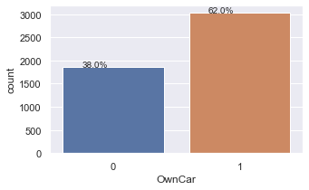

```python
perc_on_bar(Tourism_df['OwnCar'])
```

**Insights**

- Most customers own a car

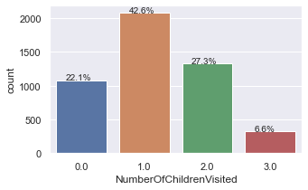

```python
perc_on_bar(Tourism_df['NumberOfChildrenVisited'])
```

**Insights**

- Roughly 65% of the customers have 1 or less children that visited

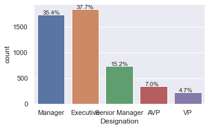

```python
perc_on_bar(Tourism_df['Designation'])
```

**Insights**

- 70% of the customers are Manager or Executive

### Bivariate analysis

Review pairplot for continuous variables

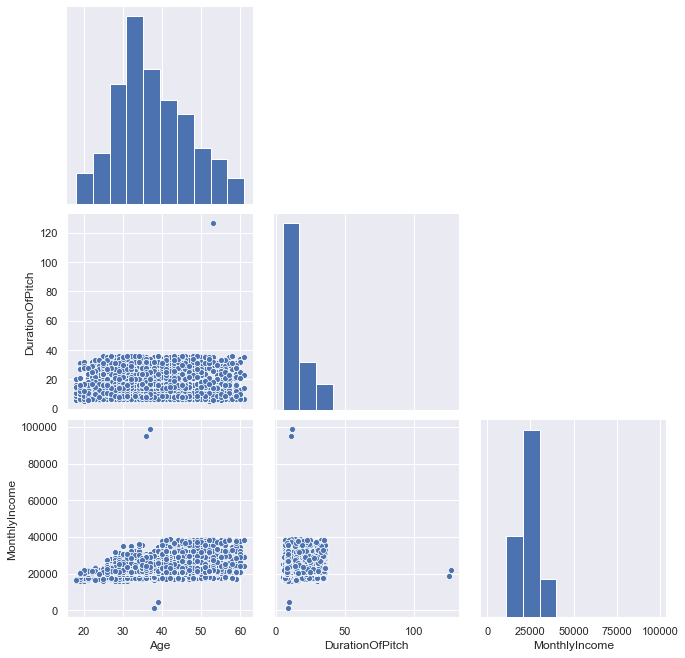

```python
columns = ['Age','DurationOfPitch','MonthlyIncome']
sns.pairplot(Tourism_df[columns], height=3, diag_kind='auto', corner=True)
plt.show()
```

**Insight**

- There is not significant correlation between Age, DurationOfPitch and MonthlyIncome

### Reviews crosstab of categorical varibles with proportion of ProdTaken

```python
pd.crosstab(Tourism_df['TypeofContact'],Tourism_df['ProdTaken'],normalize='index')
```

| ProdTaken TypeofContact | 0 | 1 |
| --- | --- | --- |
| Company Invited | 0.781536 | 0.218464 |
| Self Enquiry | 0.823751 | 0.176249 |

**Insights**

- Company Invited has a high proportions of Product Taken 21.8% to 17.6%

```python
pd.crosstab(Tourism_df['CityTier'],Tourism_df['ProdTaken'],normalize='index')
```

| ProdTaken CityTier | 0 | 1 |
| --- | --- | --- |
| 1 | 0.836991 | 0.163009 |
| 2 | 0.767677 | 0.232323 |
| 3 | 0.764000 | 0.236000 |

**Insights**

- Tiers 2 and 3 have a higher proportions of product taken compared to tier 1

```python
pd.crosstab(Tourism_df['Occupation'],Tourism_df['ProdTaken'],normalize='index')
```

| ProdTaken Occupation | 0 | 1 |
| --- | --- | --- |
| Free Lancer | 0.000000 | 1.000000 |
| Large Business | 0.723502 | 0.276498 |
| Salaried | 0.825169 | 0.174831 |
| Small Business | 0.815739 | 0.184261 |

**Insights**

- There is good seperation in product taken proportion between Large Business and Salaried and Small Business.

```python
pd.crosstab(Tourism_df['Gender'],Tourism_df['ProdTaken'],normalize='index')
```

| ProdTaken Gender | 0 | 1 |
| --- | --- | --- |
| Fe Male | 0.838710 | 0.161290 |
| Female | 0.825537 | 0.174463 |
| Male | 0.801783 | 0.198217 |

**Insights**

- There isn't much seperation between Female and Male in Product Taken proportion
- Fe Male will need to be corrected and mapped to Female

```python
pd.crosstab(Tourism_df['NumberOfPersonVisited'],Tourism_df['ProdTaken'],normalize='index')
```

| ProdTaken NumberOfPersonVisited | 0 | 1 |
| --- | --- | --- |
| 1 | 1.000000 | 0.000000 |
| 2 | 0.811707 | 0.188293 |
| 3 | 0.808493 | 0.191507 |
| 4 | 0.811891 | 0.188109 |
| 5 | 1.000000 | 0.000000 |

**Insights**

- There is not much seperation between the product taken proportion. Catergories 1 and 5 don't have many observations, so it isn't signficant that they are zero

```python
pd.crosstab(Tourism_df['NumberOfFollowups'],Tourism_df['ProdTaken'],normalize='index')
```

| ProdTaken NumberOfFollowups | 0 | 1 |
| --- | --- | --- |
| 1.0 | 0.886364 | 0.113636 |
| 2.0 | 0.895197 | 0.104803 |
| 3.0 | 0.833561 | 0.166439 |
| 4.0 | 0.816731 | 0.183269 |
| 5.0 | 0.751302 | 0.248698 |
| 6.0 | 0.602941 | 0.397059 |

**Insights**

- There is pretty good seperation in product taken proportion between the 6 catergories.

```python
pd.crosstab(Tourism_df['ProductPitched'],Tourism_df['ProdTaken'],normalize='index')
```

| ProdTaken ProductPitched | 0 | 1 |
| --- | --- | --- |
| Basic | 0.700326 | 0.299674 |
| Deluxe | 0.882217 | 0.117783 |
| King | 0.913043 | 0.086957 |
| Standard | 0.832884 | 0.167116 |
| Super Deluxe | 0.941520 | 0.058480 |

**Insights**

- There is pretty good seperation in product taken proportion between the 5 categories. Looks like Basic will be predictive of product taken

```python
pd.crosstab(Tourism_df['PreferredPropertyStar'],Tourism_df['ProdTaken'],normalize='index')
```

| ProdTaken PreferredPropertyStar | 0 | 1 |
| --- | --- | --- |
| 3.0 | 0.838958 | 0.161042 |
| 4.0 | 0.800657 | 0.199343 |
| 5.0 | 0.738494 | 0.261506 |

**Insights**

- Preferred Property Star category 5.0 has a high proportion of product taken compared to categories 3.0 and 4.0

```python
pd.crosstab(Tourism_df['MaritalStatus'],Tourism_df['ProdTaken'],normalize='index')
```

| ProdTaken MaritalStatus | 0 | 1 |
| --- | --- | --- |
| Divorced | 0.869474 | 0.130526 |
| Married | 0.860684 | 0.139316 |
| Single | 0.668122 | 0.331878 |
| Unmarried | 0.756598 | 0.243402 |

**Insights**

- MaritalStatus could be predictive since there is good variation of ProdTaken proportion between the categories. Single has ha propotion of product taken

```python
pd.crosstab(Tourism_df['NumberOfTrips'],Tourism_df['ProdTaken'],normalize='index')
```

| ProdTaken NumberOfTrips | 0 | 1 |
| --- | --- | --- |
| 1.0 | 0.819355 | 0.180645 |
| 2.0 | 0.795765 | 0.204235 |
| 3.0 | 0.798888 | 0.201112 |
| 4.0 | 0.872385 | 0.127615 |
| 5.0 | 0.864629 | 0.135371 |
| 6.0 | 0.801242 | 0.198758 |
| 7.0 | 0.715596 | 0.284404 |
| 8.0 | 0.723810 | 0.276190 |
| 19.0 | 0.000000 | 1.000000 |
| 20.0 | 0.000000 | 1.000000 |
| 21.0 | 1.000000 | 0.000000 |
| 22.0 | 1.000000 | 0.000000 |

**Insights**

- There is low credibility in the higher number categories. So, results are not stable in higher ranges

```python
pd.crosstab(Tourism_df['Passport'],Tourism_df['ProdTaken'],normalize='index')
```

| ProdTaken Passport | 0 | 1 |
| --- | --- | --- |
| 0 | 0.877092 | 0.122908 |
| 1 | 0.652602 | 0.347398 |

**Insights**

- There is good seperation product taken proportion between having a passport and not having one. This could be a predictive variable

```python
pd.crosstab(Tourism_df['PitchSatisfactionScore'],Tourism_df['ProdTaken'],normalize='index')
```

| ProdTaken PitchSatisfactionScore | 0 | 1 |
| --- | --- | --- |
| 1 | 0.847134 | 0.152866 |
| 2 | 0.849829 | 0.150171 |
| 3 | 0.786198 | 0.213802 |
| 4 | 0.822368 | 0.177632 |
| 5 | 0.783505 | 0.216495 |

**Insights**

- no clear insight

```python
pd.crosstab(Tourism_df['OwnCar'],Tourism_df['ProdTaken'],normalize='index')
```

| ProdTaken OwnCar | 0 | 1 |
| --- | --- | --- |
| 0 | 0.806034 | 0.193966 |
| 1 | 0.815303 | 0.184697 |

**Insight**

- Not much seperation in product taken proportion between owning a car and not owning a car

```python
pd.crosstab(Tourism_df['NumberOfChildrenVisited'],Tourism_df['ProdTaken'],normalize='index')
```

| ProdTaken NumberOfChildrenVisited | 0 | 1 |
| --- | --- | --- |
| 0.0 | 0.813309 | 0.186691 |
| 1.0 | 0.811538 | 0.188462 |
| 2.0 | 0.810487 | 0.189513 |
| 3.0 | 0.796923 | 0.203077 |

**Insights**

- The product taken proportion is pretty stables between the categories

```python
pd.crosstab(Tourism_df['Designation'],Tourism_df['ProdTaken'],normalize='index')
```

| ProdTaken Designation | 0 | 1 |
| --- | --- | --- |
| AVP | 0.941520 | 0.058480 |
| Executive | 0.700326 | 0.299674 |
| Manager | 0.882217 | 0.117783 |
| Senior Manager | 0.832884 | 0.167116 |
| VP | 0.913043 | 0.086957 |

**Insights**

- Executive is most likely to take a product

### Review the continous variables using distbrution plots

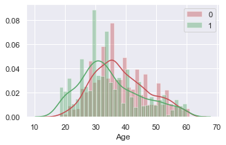

```python
sns.distplot(Tourism_df[Tourism_df['ProdTaken']==0]['Age'],color='r',label=0, bins=31)
sns.distplot(Tourism_df[Tourism_df['ProdTaken']==1]['Age'],color='g',label=1, bins=31)
plt.legend()
plt.show()
```

**Insights**

- Age looks like predictive varible. The distribution of customers who take a product is shifted to a younger age.

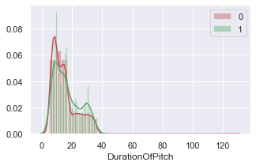

```python
sns.distplot(Tourism_df[Tourism_df['ProdTaken']==0]['DurationOfPitch'],color='r',label=0, bins=31)
sns.distplot(Tourism_df[Tourism_df['ProdTaken']==1]['DurationOfPitch'],color='g',label=1, bins=31)
plt.legend()
plt.show()
```

**Insights**

- Customers who took a product listened to longer pitches. This might be a dimesion to do reasearch on to see why longer pitches are working. Is there a particular agent that has a good approach?

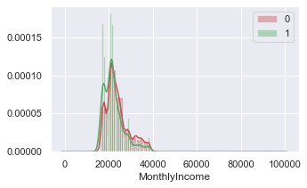

```python
sns.distplot(Tourism_df[Tourism_df['ProdTaken']==0]['MonthlyIncome'],color='r',label=0, bins=31)
sns.distplot(Tourism_df[Tourism_df['ProdTaken']==1]['MonthlyIncome'],color='g',label=1, bins=31)
plt.legend()
plt.show()
```

**Insights**

- Not seeing too much differences between the product taken and product not take distribution across Monthly Income

### Create profile for products

```python
Tourism_df.groupby(['ProductPitched']).mean()
```

| ProductPitched | ProdTaken | Age | CityTier | DurationOfPitch | NumberOfPersonVisited | NumberOfFollowups | PreferredPropertyStar | NumberOfTrips | Passport | PitchSatisfactionScore | OwnCar | NumberOfChildrenVisited | MonthlyIncome |
| --- | --- | --- | --- | --- | --- | --- | --- | --- | --- | --- | --- | --- | --- |
| Basic | 0.299674 | 33.054181 | 1.349620 | 15.194834 | 2.929967 | 3.693822 | 3.585551 | 3.096353 | 0.308360 | 3.081433 | 0.588491 | 1.199348 | 19939.922507 |
| Deluxe | 0.117783 | 37.382193 | 1.928406 | 15.935839 | 2.891455 | 3.701765 | 3.560370 | 3.282081 | 0.277136 | 3.006928 | 0.610855 | 1.177354 | 22643.157629 |
| King | 0.086957 | 48.065217 | 1.443478 | 12.100000 | 2.847826 | 3.804348 | 3.478261 | 3.344595 | 0.260870 | 3.226087 | 0.721739 | 1.358852 | 35878.947826 |
| Standard | 0.167116 | 40.581646 | 1.800539 | 15.986505 | 2.920485 | 3.791105 | 3.647773 | 3.317139 | 0.283019 | 3.061995 | 0.652291 | 1.178138 | 26637.749326 |
| Super Deluxe | 0.058480 | 48.026316 | 1.730994 | 16.230994 | 2.845029 | 3.576023 | 3.578947 | 3.589041 | 0.304094 | 3.356725 | 0.701754 | 1.073333 | 32241.046784 |

**Insights**

- Basic member take the product at a higher rate, youngest cohort and earn have the lowest monthly income

```python
Tourism_df.groupby(['ProductPitched','ProdTaken']).mean()
```

| ProductPitched | ProdTaken | Age | CityTier | DurationOfPitch | NumberOfPersonVisited | NumberOfFollowups | PreferredPropertyStar | NumberOfTrips | Passport | PitchSatisfactionScore | OwnCar | NumberOfChildrenVisited | MonthlyIncome |
| --- | --- | --- | --- | --- | --- | --- | --- | --- | --- | --- | --- | --- | --- |
| Basic | 0 | 33.822485 | 1.280620 | 14.940753 | 2.940310 | 3.583919 | 3.505818 | 3.041085 | 0.190698 | 3.024806 | 0.595349 | 1.189922 | 19844.302610 |
|  | 1 | 31.289320 | 1.510870 | 15.791353 | 2.905797 | 3.950730 | 3.771739 | 3.226691 | 0.583333 | 3.213768 | 0.572464 | 1.221416 | 20161.529301 |
| Deluxe | 0 | 37.346869 | 1.863874 | 15.517975 | 2.883508 | 3.666000 | 3.541885 | 3.226440 | 0.248691 | 3.002618 | 0.611257 | 1.178010 | 22578.242991 |
|  | 1 | 37.641414 | 2.411765 | 19.100000 | 2.950980 | 3.970000 | 3.699507 | 3.702970 | 0.490196 | 3.039216 | 0.607843 | 1.172414 | 23106.215385 |
| King | 0 | 47.985714 | 1.409524 | 12.252381 | 2.842857 | 3.757143 | 3.455497 | 3.335878 | 0.228571 | 3.219048 | 0.704762 | 1.352332 | 35993.885714 |
|  | 1 | 48.900000 | 1.800000 | 10.500000 | 2.900000 | 4.300000 | 3.750000 | 3.411765 | 0.600000 | 3.300000 | 0.900000 | 1.437500 | 34672.100000 |
| Standard | 0 | 40.496764 | 1.741100 | 15.373786 | 2.911003 | 3.762136 | 3.631068 | 3.377023 | 0.262136 | 2.980583 | 0.650485 | 1.189320 | 26758.605178 |
|  | 1 | 41.008130 | 2.096774 | 19.065041 | 2.967742 | 3.935484 | 3.731707 | 3.016260 | 0.387097 | 3.467742 | 0.661290 | 1.121951 | 26035.419355 |
| Super Deluxe | 0 | 48.307453 | 1.677019 | 16.090062 | 2.854037 | 3.605590 | 3.577640 | 3.611722 | 0.285714 | 3.329193 | 0.683230 | 1.064286 | 32391.186335 |
|  | 1 | 43.500000 | 2.600000 | 18.500000 | 2.700000 | 3.100000 | 3.600000 | 3.263158 | 0.600000 | 3.800000 | 1.000000 | 1.200000 | 29823.800000 |

**Insights**

- Customers have take product have a higher proportion of passports for ever Product pitched category

### Data Pre-processing

Prepare the data for analysis - Missing value Treatment, Outlier Detection(treat, if needed- why or why not ), Feature Engineering, Prepare data for modeling

```python
#Handle Missing Values with median value
Tourism_df.fillna(Tourism_df.median(), inplace=True)
```

```python
Tourism_df.info() #check data
```

[output not shown]

[output cut: 20 more lines]

**Insights**

- TypeofContract still has missing value since it is categorical type

```python
Tourism_df['TypeofContact'].fillna(Tourism_df['TypeofContact'].mode()[0],inplace = True) #use mode to fill in missing value
```

```python
Tourism_df.info()
```

```
<class 'pandas.core.frame.DataFrame'>
RangeIndex: 4888 entries, 0 to 4887
Data columns (total 19 columns):
 #   Column                   Non-Null Count  Dtype
---  ------                   --------------  -----
 0   ProdTaken                4888 non-null   int64
 1   Age                      4888 non-null   float64
 2   TypeofContact            4888 non-null   category
 3   CityTier                 4888 non-null   int64
 4   DurationOfPitch          4888 non-null   float64
 5   Occupation               4888 non-null   category
 6   Gender                   4888 non-null   category
 7   NumberOfPersonVisited    4888 non-null   int64
 8   NumberOfFollowups        4888 non-null   float64
 9   ProductPitched           4888 non-null   category
 10  PreferredPropertyStar    4888 non-null   float64
 11  MaritalStatus            4888 non-null   category
 12  NumberOfTrips            4888 non-null   float64
 13  Passport                 4888 non-null   int64
 14  PitchSatisfactionScore   4888 non-null   int64
 15  OwnCar                   4888 non-null   int64
 16  NumberOfChildrenVisited  4888 non-null   float64
 17  Designation              4888 non-null   category
 18  MonthlyIncome            4888 non-null   float64
dtypes: category(6), float64(7), int64(6)
memory usage: 526.2 KB
```

**Insights**

- There are no more missing values

```python
# fix remap Fe male to Female

Tourism_df['Gender'] = Tourism_df['Gender'].replace(['Fe Male'],'Female')
```

```python
# remove customer interaction data since this information won't
# be available in targeting new customers and we want this model to be generalized to new customers
# Also, dropping NumberOfFollowups and DurationOfPitch removes some of the variables that I was going to treat for outliers
Tourism_df.drop(["PitchSatisfactionScore","ProductPitched","NumberOfFollowups","DurationOfPitch"] , axis=1,inplace=True)
```

```python
# Create one hot encoding

oneHotCols=["TypeofContact","Occupation","Gender","MaritalStatus","Designation"]
```

```python
#create dummy varibles for modeling.
Tourism_df=pd.get_dummies(Tourism_df, columns=oneHotCols)
```

```python
Tourism_df.columns = Tourism_df.columns.str.replace(' ','_') #replace spaces in header with _
Tourism_df.head(10)
```

|  | ProdTaken | Age | CityTier | NumberOfPersonVisited | PreferredPropertyStar | NumberOfTrips | Passport | OwnCar | NumberOfChildrenVisited | MonthlyIncome | ... | Gender_Male | MaritalStatus_Divorced | MaritalStatus_Married | MaritalStatus_Single | MaritalStatus_Unmarried | Designation_AVP | Designation_Executive | Designation_Manager | Designation_Senior_Manager | Designation_VP |
| --- | --- | --- | --- | --- | --- | --- | --- | --- | --- | --- | --- | --- | --- | --- | --- | --- | --- | --- | --- | --- | --- |
| 0 | 1 | 41.0 | 3 | 3 | 3.0 | 1.0 | 1 | 1 | 0.0 | 20993.0 | ... | 0 | 0 | 0 | 1 | 0 | 0 | 0 | 1 | 0 | 0 |
| 1 | 0 | 49.0 | 1 | 3 | 4.0 | 2.0 | 0 | 1 | 2.0 | 20130.0 | ... | 1 | 1 | 0 | 0 | 0 | 0 | 0 | 1 | 0 | 0 |
| 2 | 1 | 37.0 | 1 | 3 | 3.0 | 7.0 | 1 | 0 | 0.0 | 17090.0 | ... | 1 | 0 | 0 | 1 | 0 | 0 | 1 | 0 | 0 | 0 |
| 3 | 0 | 33.0 | 1 | 2 | 3.0 | 2.0 | 1 | 1 | 1.0 | 17909.0 | ... | 0 | 1 | 0 | 0 | 0 | 0 | 1 | 0 | 0 | 0 |
| 4 | 0 | 36.0 | 1 | 2 | 4.0 | 1.0 | 0 | 1 | 0.0 | 18468.0 | ... | 1 | 1 | 0 | 0 | 0 | 0 | 1 | 0 | 0 | 0 |
| 5 | 0 | 32.0 | 1 | 3 | 3.0 | 1.0 | 0 | 1 | 1.0 | 18068.0 | ... | 1 | 0 | 0 | 1 | 0 | 0 | 1 | 0 | 0 | 0 |
| 6 | 0 | 59.0 | 1 | 2 | 5.0 | 5.0 | 1 | 1 | 1.0 | 17670.0 | ... | 0 | 1 | 0 | 0 | 0 | 0 | 1 | 0 | 0 | 0 |
| 7 | 0 | 30.0 | 1 | 3 | 3.0 | 2.0 | 0 | 0 | 1.0 | 17693.0 | ... | 1 | 0 | 1 | 0 | 0 | 0 | 1 | 0 | 0 | 0 |
| 8 | 0 | 38.0 | 1 | 2 | 3.0 | 1.0 | 0 | 0 | 0.0 | 24526.0 | ... | 1 | 0 | 0 | 0 | 1 | 0 | 0 | 0 | 1 | 0 |
| 9 | 0 | 36.0 | 1 | 3 | 3.0 | 7.0 | 0 | 1 | 0.0 | 20237.0 | ... | 1 | 1 | 0 | 0 | 0 | 0 | 0 | 1 | 0 | 0 |

10 rows × 27 columns

```python
Tourism_df.info()
```

```
<class 'pandas.core.frame.DataFrame'>
RangeIndex: 4888 entries, 0 to 4887
Data columns (total 27 columns):
 #   Column                         Non-Null Count  Dtype
---  ------                         --------------  -----
 0   ProdTaken                      4888 non-null   int64
 1   Age                            4888 non-null   float64
 2   CityTier                       4888 non-null   int64
 3   NumberOfPersonVisited          4888 non-null   int64
 4   PreferredPropertyStar          4888 non-null   float64
 5   NumberOfTrips                  4888 non-null   float64
 6   Passport                       4888 non-null   int64
 7   OwnCar                         4888 non-null   int64
 8   NumberOfChildrenVisited        4888 non-null   float64
 9   MonthlyIncome                  4888 non-null   float64
```

[output cut: 19 more lines]

**Insights**

- All varibles are now of the numerical type

## Split the Data

```python
X = Tourism_df.drop("ProdTaken" , axis=1)
y = Tourism_df.pop("ProdTaken")
```

```python
X_train, X_test, y_train, y_test = train_test_split(X, y, test_size=.30, random_state=1) #30% of data is in test dataset
```

# Model building

- **Since we want to target members that will buy product and save marketing dollars, recall is the appropriate metric to maximize**
- **Also, the models we are using deal well with outliers, so I am not going to treat the outliers**

### Build Decision Tree Model

```python
dTree = DecisionTreeClassifier(criterion = 'gini', random_state=1)
dTree.fit(X_train, y_train)
```

```
DecisionTreeClassifier(random_state=1)
```

### Scoring our Decision Tree

```python
## Function to create confusion matrix
def make_confusion_matrix(model,y_actual,labels=[1, 0]):

    y_predict = model.predict(X_test)
    cm=metrics.confusion_matrix( y_actual, y_predict, labels=[0, 1])
    df_cm = pd.DataFrame(cm, index = [i for i in ["Actual - No","Actual - Yes"]],
                  columns = [i for i in ['Predicted - No','Predicted - Yes']])
    group_counts = ["{0:0.0f}".format(value) for value in
                cm.flatten()]
    group_percentages = ["{0:.2%}".format(value) for value in
                         cm.flatten()/np.sum(cm)]
    labels = [f"{v1}\n{v2}" for v1, v2 in
              zip(group_counts,group_percentages)]
    labels = np.asarray(labels).reshape(2,2)
    plt.figure(figsize = (10,7))
    sns.heatmap(df_cm, annot=labels,fmt='')
    plt.ylabel('True label')
    plt.xlabel('Predicted label')
```

```python
##  Function to calculate Accuracy, Recall and Precision
def get_metrics_score(model,flag=True):

    # defining an empty list to store train and test results
    score_list=[]

    #Predicting on train and tests
    pred_train = model.predict(X_train)
    pred_test = model.predict(X_test)

    #Accuracy
    train_acc = model.score(X_train,y_train)
    test_acc = model.score(X_test,y_test)

    #Recall
    train_recall = metrics.recall_score(y_train,pred_train)
    test_recall = metrics.recall_score(y_test,pred_test)

    #Precision
    train_precision = metrics.precision_score(y_train,pred_train)
    test_precision = metrics.precision_score(y_test,pred_test)

    score_list.extend((train_acc,test_acc,train_recall,test_recall,train_precision,test_precision))


    if flag == True:
        print("Accuracy on training set : ",model.score(X_train,y_train))
        print("Accuracy on test set : ",model.score(X_test,y_test))
        print("Recall on training set : ",metrics.recall_score(y_train,pred_train))
        print("Recall on test set : ",metrics.recall_score(y_test,pred_test))
        print("Precision on training set : ",metrics.precision_score(y_train,pred_train))
        print("Precision on test set : ",metrics.precision_score(y_test,pred_test))

    return score_list # returning the list
```

```python
get_metrics_score(dTree)
```

```
Accuracy on training set :  1.0
Accuracy on test set :  0.8711656441717791
Recall on training set :  1.0
Recall on test set :  0.6385135135135135
Precision on training set :  1.0
Precision on test set :  0.6974169741697417
```

```
[1.0, 0.8711656441717791, 1.0, 0.6385135135135135, 1.0, 0.6974169741697417]
```

[figure not shown]

```python
make_confusion_matrix(dTree,y_test)
```

**Insights**

- The decision tree without any hyperparameters overfitted the model. As, you can tell by the 100% accuracy on training data and 87% accuracy on the test data set.
- This model will not generalize well and can be improved on

```python
feature_names = list(X.columns)
print(feature_names)
```

```
['Age', 'CityTier', 'NumberOfPersonVisited', 'PreferredPropertyStar', 'NumberOfTrips', 'Passport', 'OwnCar', 'NumberOfChildrenVisited', 'MonthlyIncome', 'TypeofContact_Company_Invited', 'TypeofContact_Self_Enquiry', 'Occupation_Free_Lancer', 'Occupation_Large_Business', 'Occupation_Salaried', 'Occup…
```

### Plot of tree

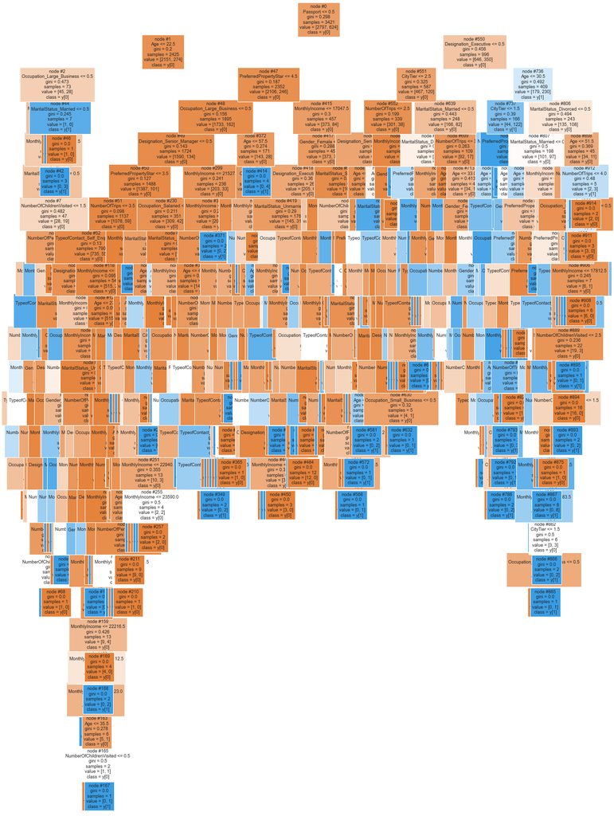

```python
plt.figure(figsize=(20,30))
tree.plot_tree(dTree,feature_names=feature_names,filled=True,fontsize=9,node_ids=True,class_names=True)
plt.show()
```

```python
print(tree.export_text(dTree,feature_names=feature_names,show_weights=True))
```

```
|--- Passport <= 0.50
|   |--- Age <= 22.50
|   |   |--- Occupation_Large_Business <= 0.50
|   |   |   |--- MonthlyIncome <= 21427.50
|   |   |   |   |--- MonthlyIncome <= 21356.50
|   |   |   |   |   |--- MaritalStatus_Single <= 0.50
|   |   |   |   |   |   |--- weights: [9.00, 0.00] class: 0
|   |   |   |   |   |--- MaritalStatus_Single >  0.50
|   |   |   |   |   |   |--- NumberOfChildrenVisited <= 1.50
|   |   |   |   |   |   |   |--- NumberOfTrips <= 2.50
|   |   |   |   |   |   |   |   |--- MonthlyIncome <= 17749.50
|   |   |   |   |   |   |   |   |   |--- MonthlyIncome <= 17685.50
|   |   |   |   |   |   |   |   |   |   |--- NumberOfChildrenVisited <= 0.50
|   |   |   |   |   |   |   |   |   |   |   |--- truncated branch of depth 5
|   |   |   |   |   |   |   |   |   |   |--- NumberOfChildrenVisited >  0.50
|   |   |   |   |   |   |   |   |   |   |   |--- truncated branch of depth 3
|   |   |   |   |   |   |   |   |   |--- MonthlyIncome >  17685.50
|   |   |   |   |   |   |   |   |   |   |--- weights: [0.00, 3.00] class: 1
|   |   |   |   |   |   |   |   |--- MonthlyIncome >  17749.50
|   |   |   |   |   |   |   |   |   |--- weights: [7.00, 0.00] class: 0
|   |   |   |   |   |   |   |--- NumberOfTrips >  2.50
|   |   |   |   |   |   |   |   |--- MonthlyIncome <= 20976.00
|   |   |   |   |   |   |   |   |   |--- TypeofContact_Self_Enquiry <= 0.50
|   |   |   |   |   |   |   |   |   |   |--- MonthlyIncome <= 20387.00
|   |   |   |   |   |   |   |   |   |   |   |--- weights: [1.00, 0.00] class: 0
|   |   |   |   |   |   |   |   |   |   |--- MonthlyIncome >  20387.00
|   |   |   |   |   |   |   |   |   |   |   |--- weights: [0.00, 2.00] class: 1
|   |   |   |   |   |   |   |   |   |--- TypeofContact_Self_Enquiry >  0.50
|   |   |   |   |   |   |   |   |   |   |--- weights: [0.00, 5.00] class: 1
|   |   |   |   |   |   |   |   |--- MonthlyIncome >  20976.00
|   |   |   |   |   |   |   |   |   |--- weights: [1.00, 0.00] class: 0
|   |   |   |   |   |   |--- NumberOfChildrenVisited >  1.50
|   |   |   |   |   |   |   |--- NumberOfPersonVisited <= 3.50
|   |   |   |   |   |   |   |   |--- Gender_Male <= 0.50
|   |   |   |   |   |   |   |   |   |--- Age <= 20.00
|   |   |   |   |   |   |   |   |   |   |--- weights: [1.00, 0.00] class: 0
|   |   |   |   |   |   |   |   |   |--- Age >  20.00
|   |   |   |   |   |   |   |   |   |   |--- weights: [0.00, 2.00] class: 1
|   |   |   |   |   |   |   |   |--- Gender_Male >  0.50
|   |   |   |   |   |   |   |   |   |--- weights: [2.00, 0.00] class: 0
```

[output cut: 801 more lines]

```
|   |   |   |   |   |   |   |--- OwnCar >  0.50
|   |   |   |   |   |   |   |   |--- MonthlyIncome <= 17812.50
|   |   |   |   |   |   |   |   |   |--- weights: [0.00, 1.00] class: 1
|   |   |   |   |   |   |   |   |--- MonthlyIncome >  17812.50
|   |   |   |   |   |   |   |   |   |--- weights: [6.00, 0.00] class: 0
|   |   |   |   |   |--- NumberOfTrips >  5.50
|   |   |   |   |   |   |--- Age <= 37.00
|   |   |   |   |   |   |   |--- weights: [0.00, 4.00] class: 1
|   |   |   |   |   |   |--- Age >  37.00
|   |   |   |   |   |   |   |--- weights: [3.00, 0.00] class: 0
|   |   |   |   |--- Age >  51.50
|   |   |   |   |   |--- NumberOfTrips <= 4.00
|   |   |   |   |   |   |--- weights: [0.00, 3.00] class: 1
|   |   |   |   |   |--- NumberOfTrips >  4.00
|   |   |   |   |   |   |--- weights: [2.00, 0.00] class: 0
```

```python
print (pd.DataFrame(dTree.feature_importances_, columns = ["Imp"], index = X_train.columns).sort_values(by = 'Imp', ascending = False))
```

```
                                    Imp
Age                            0.189901
MonthlyIncome                  0.174938
NumberOfTrips                  0.089923
Passport                       0.078662
Designation_Executive          0.069461
CityTier                       0.056622
OwnCar                         0.030502
PreferredPropertyStar          0.029731
NumberOfChildrenVisited        0.029647
Occupation_Small_Business      0.028644
TypeofContact_Self_Enquiry     0.028451
TypeofContact_Company_Invited  0.023720
NumberOfPersonVisited          0.020980
Gender_Female                  0.020894
Gender_Male                    0.020702
MaritalStatus_Married          0.017865
MaritalStatus_Divorced         0.015783
MaritalStatus_Single           0.015704
Occupation_Large_Business      0.014846
MaritalStatus_Unmarried        0.013594
Occupation_Salaried            0.011002
Designation_Senior_Manager     0.008205
Designation_AVP                0.005447
Designation_Manager            0.004775
Occupation_Free_Lancer         0.000000
Designation_VP                 0.000000
```

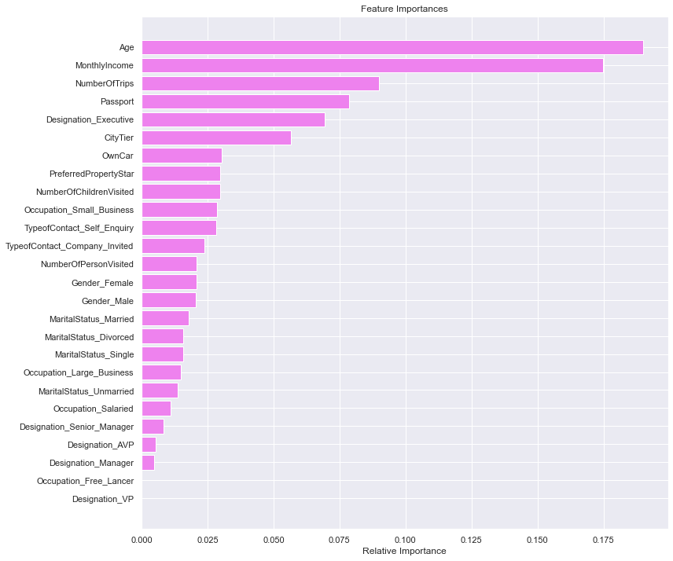

```python
importances = dTree.feature_importances_
indices = np.argsort(importances)

plt.figure(figsize=(12,12))
plt.title('Feature Importances')
plt.barh(range(len(indices)), importances[indices], color='violet', align='center')
plt.yticks(range(len(indices)), [feature_names[i] for i in indices])
plt.xlabel('Relative Importance')
plt.show()
```

**Insights**

- Age and monthly income are the most important features

### Build Decision Tree Model using Grid search

```python
from sklearn.model_selection import GridSearchCV
```

```python
# Choose the type of classifier.
dtree_tuned = DecisionTreeClassifier(random_state=1)

# Grid of parameters to choose from
## add from article
parameters = {
               "class_weight": [{0: 0.20, 1: 0.8}],
               'max_depth': np.arange(1,20),
              'min_samples_leaf': [1, 2, 5, 7, 10,15,20],
              'max_leaf_nodes' : [2, 3, 5, 10],
              'min_impurity_decrease': [0.001,0.01,0.1]
             }

# Type of scoring used to compare parameter combinations
acc_scorer = metrics.make_scorer(metrics.recall_score)


# Run the grid search
t1 = datetime.now()
grid_obj = GridSearchCV(dtree_tuned, parameters, scoring=acc_scorer,cv=5,verbose=10,n_jobs=-1)
grid_obj = grid_obj.fit(X_train, y_train)
t2 =datetime.now()
print("Grid Search takes %0.2f mins"%((t2-t1).seconds/60))

dtree_tuned = grid_obj.best_estimator_

# Fit the best algorithm to the data.
dtree_tuned.fit(X_train, y_train)
```

```
Fitting 5 folds for each of 1596 candidates, totalling 7980 fits
```

[output not shown]

```
Grid Search takes 0.67 mins
```

```
DecisionTreeClassifier(class_weight={0: 0.2, 1: 0.8}, max_depth=5,
                       max_leaf_nodes=10, min_impurity_decrease=0.001,
                       random_state=1)
```

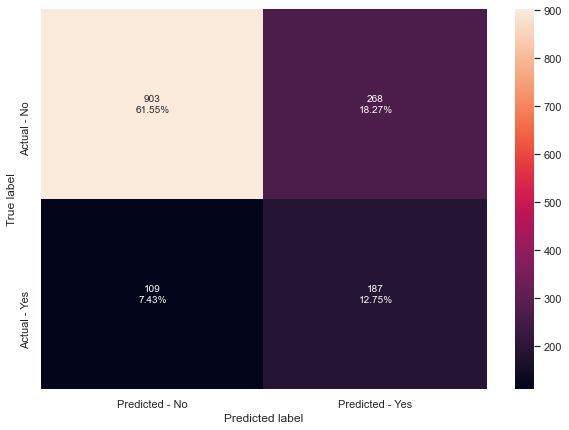

```python
make_confusion_matrix(dtree_tuned,y_test)
```

```python
get_metrics_score(dtree_tuned)
```

```
Accuracy on training set :  0.7600116924875767
Accuracy on test set :  0.7430129516019086
Recall on training set :  0.6875
Recall on test set :  0.6317567567567568
Precision on training set :  0.4066350710900474
Precision on test set :  0.41098901098901097
```

```
[0.7600116924875767,
 0.7430129516019086,
 0.6875,
 0.6317567567567568,
 0.4066350710900474,
 0.41098901098901097]
```

**Insights**

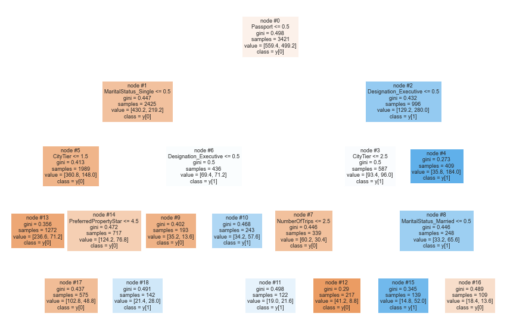

```python
plt.figure(figsize=(15,10))

tree.plot_tree(dtree_tuned,feature_names=feature_names,filled=True,fontsize=9,node_ids=True,class_names=True)
plt.show()
```

```python
# Text report showing the rules of a decision tree -

print(tree.export_text(dtree_tuned,feature_names=feature_names,show_weights=True))
```

```
|--- Passport <= 0.50
|   |--- MaritalStatus_Single <= 0.50
|   |   |--- CityTier <= 1.50
|   |   |   |--- weights: [236.60, 71.20] class: 0
|   |   |--- CityTier >  1.50
|   |   |   |--- PreferredPropertyStar <= 4.50
|   |   |   |   |--- weights: [102.80, 48.80] class: 0
|   |   |   |--- PreferredPropertyStar >  4.50
|   |   |   |   |--- weights: [21.40, 28.00] class: 1
|   |--- MaritalStatus_Single >  0.50
|   |   |--- Designation_Executive <= 0.50
|   |   |   |--- weights: [35.20, 13.60] class: 0
|   |   |--- Designation_Executive >  0.50
|   |   |   |--- weights: [34.20, 57.60] class: 1
|--- Passport >  0.50
|   |--- Designation_Executive <= 0.50
|   |   |--- CityTier <= 2.50
|   |   |   |--- NumberOfTrips <= 2.50
|   |   |   |   |--- weights: [19.00, 21.60] class: 1
|   |   |   |--- NumberOfTrips >  2.50
|   |   |   |   |--- weights: [41.20, 8.80] class: 0
|   |   |--- CityTier >  2.50
|   |   |   |--- MaritalStatus_Married <= 0.50
|   |   |   |   |--- weights: [14.80, 52.00] class: 1
|   |   |   |--- MaritalStatus_Married >  0.50
|   |   |   |   |--- weights: [18.40, 13.60] class: 0
|   |--- Designation_Executive >  0.50
|   |   |--- weights: [35.80, 184.00] class: 1
```

```python
# importance of features in the tree building

print (pd.DataFrame(dtree_tuned.feature_importances_, columns = ["Imp"], index = X_train.columns).sort_values(by = 'Imp', ascending = False))
```

```
                                    Imp
Passport                       0.457883
Designation_Executive          0.227177
CityTier                       0.119291
MaritalStatus_Single           0.077639
NumberOfTrips                  0.043092
MaritalStatus_Married          0.041010
PreferredPropertyStar          0.033908
Age                            0.000000
Gender_Female                  0.000000
Designation_Senior_Manager     0.000000
Designation_Manager            0.000000
Designation_AVP                0.000000
MaritalStatus_Unmarried        0.000000
MaritalStatus_Divorced         0.000000
Gender_Male                    0.000000
Occupation_Salaried            0.000000
Occupation_Small_Business      0.000000
Occupation_Large_Business      0.000000
Occupation_Free_Lancer         0.000000
TypeofContact_Self_Enquiry     0.000000
TypeofContact_Company_Invited  0.000000
MonthlyIncome                  0.000000
NumberOfChildrenVisited        0.000000
OwnCar                         0.000000
NumberOfPersonVisited          0.000000
Designation_VP                 0.000000
```

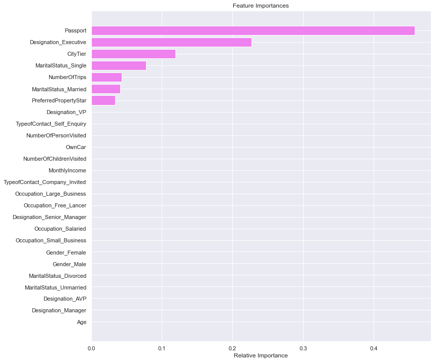

```python
importances = dtree_tuned.feature_importances_
indices = np.argsort(importances)

plt.figure(figsize=(12,12))
plt.title('Feature Importances')
plt.barh(range(len(indices)), importances[indices], color='violet', align='center')
plt.yticks(range(len(indices)), [feature_names[i] for i in indices])
plt.xlabel('Relative Importance')
plt.show()
```

**Insight**

- Passport and Desgination_Executive are the most important variables according to the tuned decision tree